# TSE Final Project

Sinenhlanhla N. Dlamini

2024-12-01

## 1. Collect daily data for the past five (5) years for the S&P 500 and five (5) individual stocks from online sources such as Yahoo Finance, FRED, or OANDA.

```r
symbols <- c("^GSPC", "BX","BLK", "BRK-B", "JPM", "WFC")
getSymbols(symbols, src = "yahoo", from = "2019-12-07", to = "2024-12-07")
```

```
## [1] "GSPC"  "BX"    "BLK"   "BRK-B" "JPM"   "WFC"
```

```r
SP500 <- Cl(GSPC)
Blackstone <- Cl(BX)
Blackrock <- Cl(BLK)
JPMorgan <- Cl(JPM)
WellFargo <- Cl(WFC)
Berkshire <- Cl(`BRK-B`)

sp500_data <- ts(SP500, frequency=252)
blackstone_data <- ts(Blackstone, frequency=252)
blackrock_data <- ts(Blackrock, frequency=252)
jpmorgan_data <- ts(JPMorgan, frequency=252)
wellsfargo_data <- ts(WellFargo, frequency=252)
berkshire_data <- ts(Berkshire, frequency=252)
```

## 2. Visualize the time series data. Assess whether the series exhibit stationarity.

```r
merged_data <- cbind(sp500_data, blackstone_data, blackrock_data, jpmorgan_data, wellsfargo_data, berkshire_data)
head(merged_data)
```

```
##      sp500_data blackstone_data blackrock_data jpmorgan_data wellsfargo_data
## [1,]    3135.96           54.14         497.07        134.41           53.92
## [2,]    3132.52           54.41         494.03        134.50           53.69
## [3,]    3141.63           54.92         493.91        134.18           53.17
## [4,]    3168.57           54.17         502.12        138.02           54.36
## [5,]    3168.80           53.63         498.61        136.81           53.79
## [6,]    3191.45           54.53         502.05        137.34           54.22
##      berkshire_data
## [1,]         221.38
## [2,]         221.26
## [3,]         222.57
## [4,]         225.92
## [5,]         225.37
## [6,]         226.85
```

```r
columns <- c("S&P 500", "Blackstone", "Blackrock", "JP Morgan", "Wells Fargo & Co", "Berkshire Hathaway")
colnames(merged_data) <- columns

head(merged_data)
```

```
##      S&P 500 Blackstone Blackrock JP Morgan Wells Fargo & Co Berkshire Hathaway
## [1,] 3135.96      54.14    497.07    134.41            53.92             221.38
## [2,] 3132.52      54.41    494.03    134.50            53.69             221.26
## [3,] 3141.63      54.92    493.91    134.18            53.17             222.57
## [4,] 3168.57      54.17    502.12    138.02            54.36             225.92
## [5,] 3168.80      53.63    498.61    136.81            53.79             225.37
## [6,] 3191.45      54.53    502.05    137.34            54.22             226.85
```

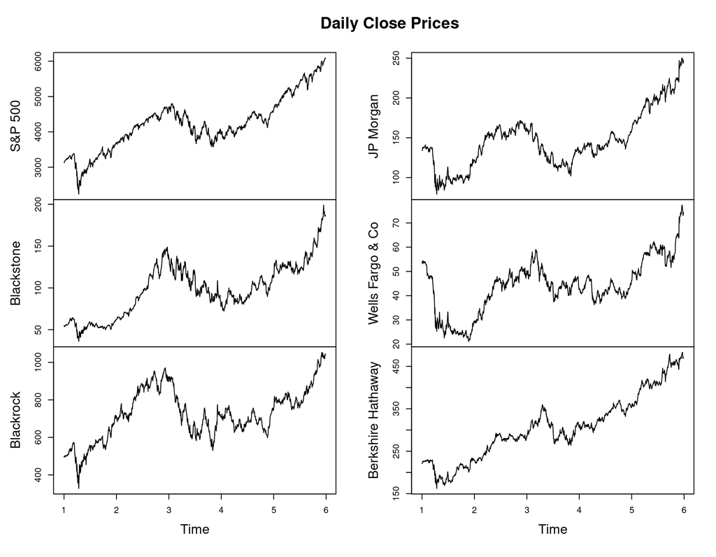

```r
plot(merged_data, main = "Daily Close Prices", col = 1:ncol(merged_data))
```

Just by looking at the graphs, the data appears to be non-stationary. Therefore there is a need to difference the data as to get data that is stationary for the analysis that is less complex as compared to when the data is non-stationary.

Using the ADF test, we test to see if we can reject the null hypothesis that the data is non-stationary.

```r
library(tseries)
adf_test <- sapply(merged_data, function(v) adf.test(v, alternative = "stationary")$p.value)
adf_test
```

```
##            S&P 500         Blackstone          Blackrock          JP Morgan
##          0.7845751          0.8265006          0.6557535          0.8866418
##   Wells Fargo & Co Berkshire Hathaway
##          0.3153260          0.3745450
```

```r
nonstationary_series <- names(adf_test[adf_test > 0.05])
nonstationary_series
```

```
## [1] "S&P 500"            "Blackstone"         "Blackrock"
## [4] "JP Morgan"          "Wells Fargo & Co"   "Berkshire Hathaway"
```

The ADF test confirms that the data is indeed non-stationary as the p-values for each series are >0.05 meaning we fail to reject the null hypothesis of non-stationarity.

## 3. For any series identified as nonstationary, apply appropriate transformations (e.g., differencing or logarithmic transformations) and plot the adjusted series.

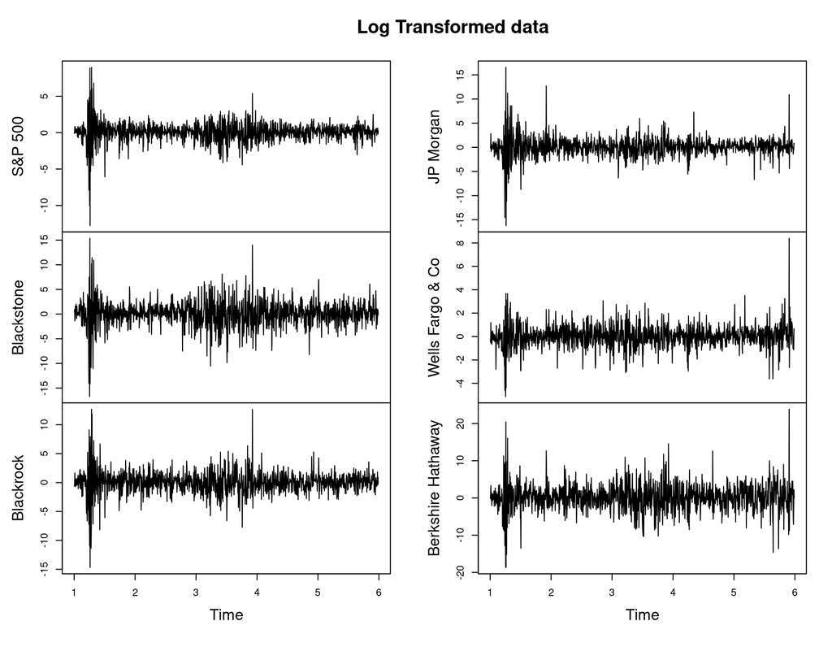

```r
transformed_data <- cbind(100*diff(log(sp500_data)), 100*diff(log(blackstone_data)), 100*diff(log(blackrock_data)), 100*diff(log(jpmorgan_data)), diff(wellsfargo_data), diff(berkshire_data))
colnames(transformed_data) <- columns
plot(transformed_data, main = "Log Transformed data", col = 1:ncol(merged_data))
```

```r
adf_test <- sapply(transformed_data, function(series) adf.test(series, alternative = "stationary")$p.value)
adf_test
```

```
##            S&P 500         Blackstone          Blackrock          JP Morgan
##               0.01               0.01               0.01               0.01
##   Wells Fargo & Co Berkshire Hathaway
##               0.01               0.01
```

We transform each series individually and test if we can reject our null hypothesis, which is non-stationarity. By looking at the plots, the data now looks stationary.

## 4. Perform formal stationarity tests on the series.

I use the ADF test and the KPSS test to formally test for stationarity

```r
stationary_data <- transformed_data

stationarity_test <- apply(stationary_data, 2, function(series) {
  list(
    ADF_p_value = adf.test(series)$p.value,
    KPSS_p_value = kpss.test(series)$p.value
  )
})
print(stationarity_test)
```

```
## $`S&P 500`
## $`S&P 500`$ADF_p_value
## [1] 0.01
##
## $`S&P 500`$KPSS_p_value
## [1] 0.1
##
##
## $Blackstone
## $Blackstone$ADF_p_value
## [1] 0.01
##
## $Blackstone$KPSS_p_value
## [1] 0.1
##
##
## $Blackrock
## $Blackrock$ADF_p_value
## [1] 0.01
##
## $Blackrock$KPSS_p_value
## [1] 0.1
##
##
## $`JP Morgan`
## $`JP Morgan`$ADF_p_value
## [1] 0.01
##
## $`JP Morgan`$KPSS_p_value
## [1] 0.1
##
##
## $`Wells Fargo & Co`
## $`Wells Fargo & Co`$ADF_p_value
## [1] 0.01
##
## $`Wells Fargo & Co`$KPSS_p_value
## [1] 0.08646441
##
##
## $`Berkshire Hathaway`
## $`Berkshire Hathaway`$ADF_p_value
## [1] 0.01
##
## $`Berkshire Hathaway`$KPSS_p_value
## [1] 0.1
```

```r
stationarity_table <- do.call(rbind, lapply(stationarity_test, function(result) {
  data.frame(
    ADF_p_value = result$ADF_p_value,
    Stationary_ADF = ifelse(result$ADF_p_value < 0.05, "Yes", "No"),
    KPSS_p_value = result$KPSS_p_value,
    Stationary_KPSS = ifelse(result$KPSS_p_value > 0.05, "Yes", "No")
  )
}))

rownames(stationarity_table) <- colnames(transformed_data)

# View the table
print(stationarity_table)
```

```
##                    ADF_p_value Stationary_ADF KPSS_p_value Stationary_KPSS
## S&P 500                   0.01            Yes   0.10000000             Yes
## Blackstone                0.01            Yes   0.10000000             Yes
## Blackrock                 0.01            Yes   0.10000000             Yes
## JP Morgan                 0.01            Yes   0.10000000             Yes
## Wells Fargo & Co          0.01            Yes   0.08646441             Yes
## Berkshire Hathaway        0.01            Yes   0.10000000             Yes
```

## 5. Determine the optimal lag length for a Vector Autoregression (VAR) model.

```r
lag_selection <- VARselect(stationary_data, lag.max = 10, type = "none")
lag_selection$criteria
```

```
##                1         2         3         4         5         6         7
## AIC(n)  3.217635  3.217566  3.229528  3.238098  3.238975  3.256100  3.260118
## HQ(n)   3.273301  3.328898  3.396525  3.460761  3.517303  3.590094  3.649778
## SC(n)   3.365691  3.513678  3.673696  3.830322  3.979255  4.144436  4.296510
## FPE(n) 24.969009 24.967367 25.268021 25.485930 25.508973 25.950633 26.056590
##                8         9        10
## AIC(n)  3.270601  3.265074  3.295321
## HQ(n)   3.715927  3.766066  3.851979
## SC(n)   4.455049  4.597578  4.775881
## FPE(n) 26.333165 26.190569 26.998114
```

```r
optimal_lag <- lag_selection$selection[1]
optimal_lag
```

```
## AIC(n)
##      2
```

The optimal lag for this VAR model is lag 2 based on the AIC value. Therefore we continue with the lag 2, also the BIC suggests a lag 1 as optimal for this model.

## 6. Estimate a VAR model based on the series.

```r
model_estimate <- VAR(transformed_data, p = optimal_lag, type = "none")

stargazer(model_estimate[[1]], type = "text", float = TRUE,
          column.sp.width = "1pt", font.size = "scriptsize",
          report = "vc", header = F, single.row = FALSE,
          digits = 3, p.auto = F, df=F)
```

```
##
## ==========================================================================
##                                       Dependent variable:
##                       ----------------------------------------------------
##                                                y
##                         (1)      (2)     (3)      (4)      (5)      (6)
## --------------------------------------------------------------------------
## S.P.500.l1             -0.248  -0.250   -0.206   -0.263   -0.087   -0.545
##
## Blackstone.l1          0.032    0.029   0.044    0.024    0.019    0.067
##
## Blackrock.l1           0.105    0.198   0.107    0.139    0.032    0.206
##
## JP.Morgan.l1           -0.099  -0.125   -0.135   -0.150   -0.047   -0.116
##
## Wells.Fargo...Co.l1    0.102    0.126   0.182    0.112    0.039    0.024
##
## Berkshire.Hathaway.l1  -0.005  -0.009   -0.031   0.003    0.010    0.048
##
## S.P.500.l2             0.095    0.008   0.180    0.171    0.024    0.087
##
## Blackstone.l2          -0.034  -0.057   -0.079   -0.035   -0.013   -0.060
##
## Blackrock.l2           -0.037  -0.053   -0.071   -0.080   -0.038   -0.096
##
## JP.Morgan.l2           0.122    0.155   0.174    0.108    0.079    0.207
##
## Wells.Fargo...Co.l2    -0.040  -0.072   -0.130   0.065    -0.003   0.067
##
## Berkshire.Hathaway.l2  -0.011   0.004   -0.012   -0.038   -0.016   -0.011
##
## --------------------------------------------------------------------------
## Observations           1,255    1,255   1,255    1,255    1,255    1,255
## R2                     0.075    0.020   0.050    0.044    0.023    0.029
## Adjusted R2            0.066    0.011   0.041    0.035    0.014    0.019
## Residual Std. Error    1.302    2.592   1.943    2.010    0.967    3.597
## F Statistic           8.358*** 2.125** 5.487*** 4.798*** 2.448*** 3.042***
## ==========================================================================
## Note:                                          *p<0.1; **p<0.05; ***p<0.01
##
## ===
## 1pt
## ---
```

## 7. Generate forecasts for each series using the fitted VAR model.

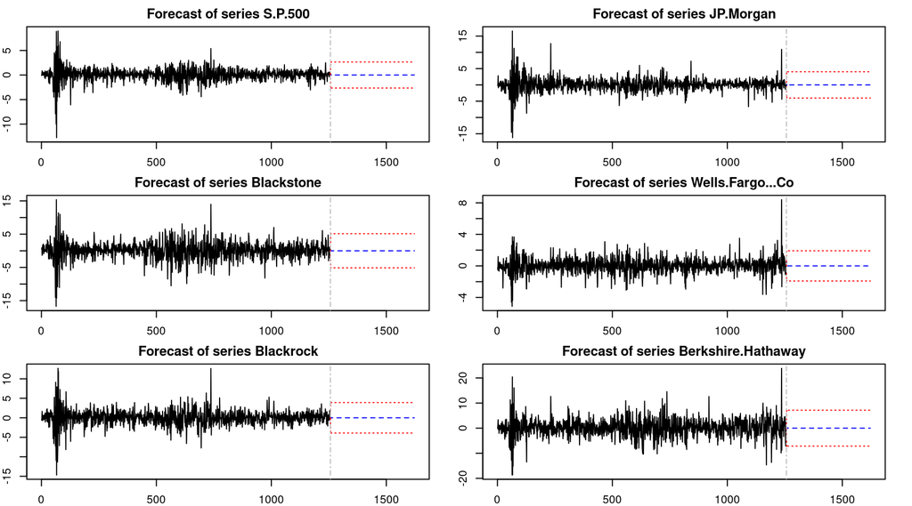

```r
forecast.series <- predict(model_estimate, n.ahead = 365)
par(mai = rep(0.4, 4)) ; plot(forecast.series)
```

## 8. Examine the impact of shocks to the S&P 500 on the other series within the VAR framework. Provide a detailed interpretation of the findings.

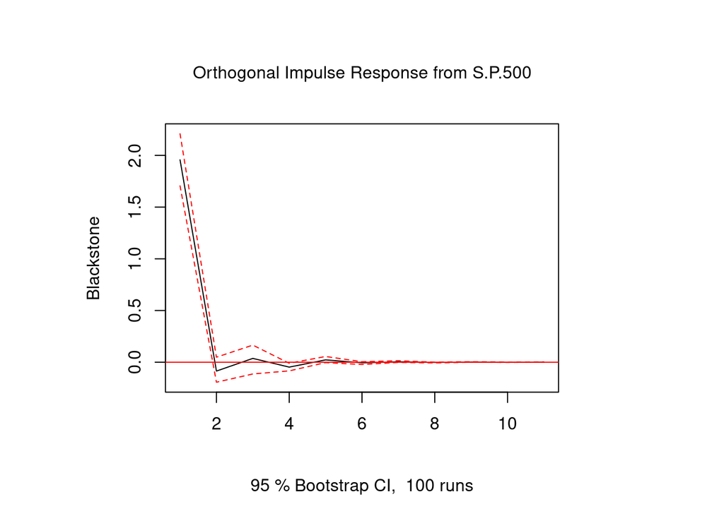

```r
irf_blackstone <- irf(model_estimate, impulse = "S.P.500", response = "Blackstone")
plot(irf_blackstone)
```

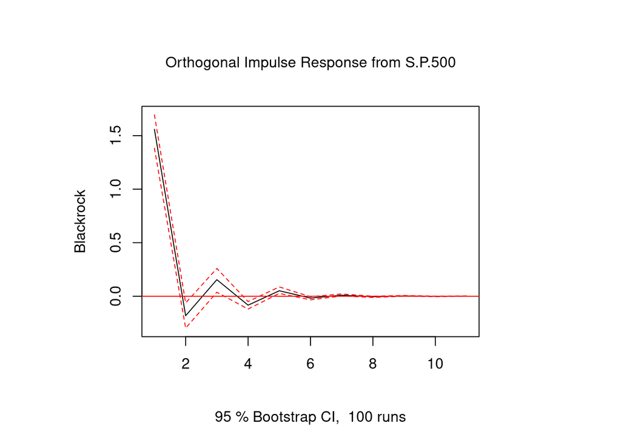

```r
irf_blackrock <- irf(model_estimate, impulse = "S.P.500", response = "Blackrock")
plot(irf_blackrock)
```

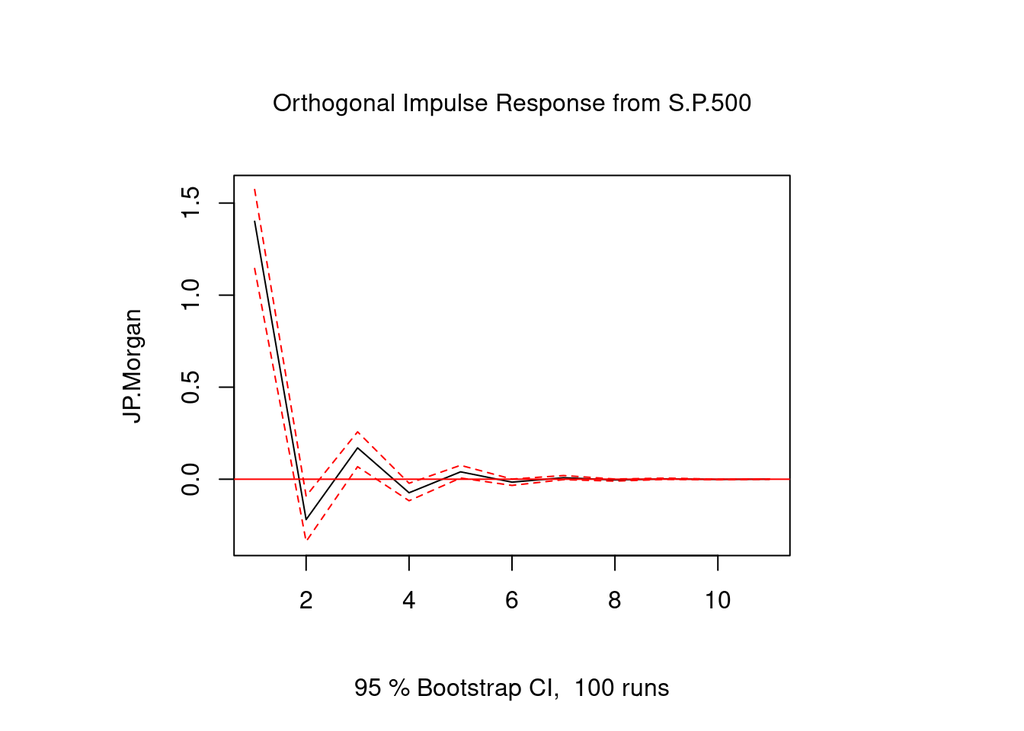

```r
irf_jpmorgan <- irf(model_estimate, impulse = "S.P.500", response = "JP.Morgan")
plot(irf_jpmorgan)
```

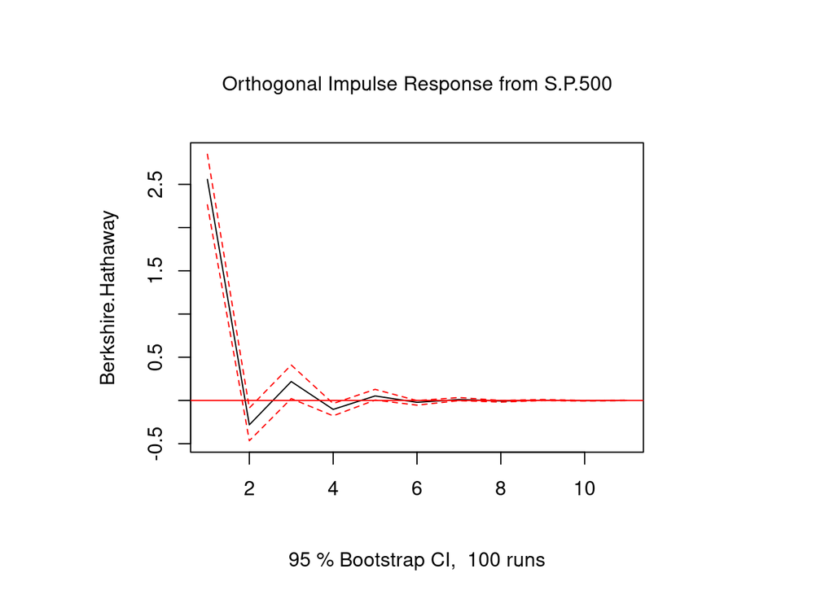

```r
irf_berkshire <- irf(model_estimate, impulse = "S.P.500", response = "Berkshire.Hathaway")
plot(irf_berkshire)
```

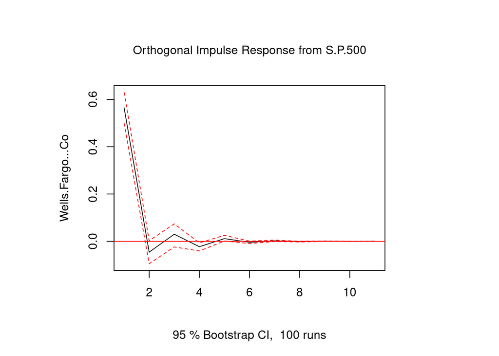

```r
irf_wellsfargo <- irf(model_estimate, impulse = "S.P.500", response = "Wells.Fargo...Co")
plot(irf_wellsfargo)
```

```r
irf_blackstone
```

```
##
## Impulse response coefficients
## $S.P.500
##          Blackstone
##  [1,]  1.9574159312
##  [2,] -0.0859064841
##  [3,]  0.0367306389
##  [4,] -0.0476044743
##  [5,]  0.0225455592
##  [6,] -0.0063628046
##  [7,]  0.0036786977
##  [8,] -0.0019079129
##  [9,]  0.0008450540
## [10,] -0.0003817445
## [11,]  0.0001861136
```

[output cut: 32 more lines]

```r
irf_jpmorgan
```

```
##
## Impulse response coefficients
## $S.P.500
##           JP.Morgan
##  [1,]  1.4009186121
##  [2,] -0.2192361776
##  [3,]  0.1703226885
##  [4,] -0.0734779333
##  [5,]  0.0400183413
##  [6,] -0.0158688203
##  [7,]  0.0079988622
##  [8,] -0.0037636103
##  [9,]  0.0017781683
## [10,] -0.0008200373
## [11,]  0.0003905676
```

[output cut: 32 more lines]

```r
irf_blackrock
```

```
##
## Impulse response coefficients
## $S.P.500
##           Blackrock
##  [1,]  1.5589217812
##  [2,] -0.1822965466
##  [3,]  0.1546125074
##  [4,] -0.0836820475
##  [5,]  0.0510019131
##  [6,] -0.0176416043
##  [7,]  0.0093370694
##  [8,] -0.0044509711
##  [9,]  0.0021238584
## [10,] -0.0009615455
## [11,]  0.0004622401
```

[output cut: 32 more lines]

```r
irf_wellsfargo
```

```
##
## Impulse response coefficients
## $S.P.500
##       Wells.Fargo...Co
##  [1,]     0.5650446776
##  [2,]    -0.0456899715
##  [3,]     0.0300771781
##  [4,]    -0.0227093978
##  [5,]     0.0114720451
##  [6,]    -0.0041542899
##  [7,]     0.0020078882
##  [8,]    -0.0010265954
##  [9,]     0.0004689291
## [10,]    -0.0002157521
## [11,]     0.0001026906
```

[output cut: 32 more lines]

```r
irf_berkshire
```

```
##
## Impulse response coefficients
## $S.P.500
##       Berkshire.Hathaway
##  [1,]       2.5578047293
##  [2,]      -0.2818120141
##  [3,]       0.2188860393
##  [4,]      -0.1033989943
##  [5,]       0.0523321051
##  [6,]      -0.0213762976
##  [7,]       0.0105422066
##  [8,]      -0.0050630015
##  [9,]       0.0023365390
## [10,]      -0.0010933664
## [11,]       0.0005174493
```

[output cut: 32 more lines]

### Interpretation of the results.

Blackstone reacts strongly to the shocks in the S&P 500, with a response shock of 1.96 at a 95% confidence interval of [1.71, 2.21]. The positive reponse and statistical significance reflect its market sensitivity. In period 2, the response is slightly negative but is small, with a response shock of -0.086. The persistence period for Blackstone is approximately 7 periods, with responses alternating between small positive and negative values, before approaching zero by period 11.

Blackrock has a response to the S&P 500 shock of 1.56 with a confidence interval of 95% between [1.38, 1.69]. The response is positive reflecting that it is an asset management firm that is sensitive to market fluctuations. The response is persistent for approximately 8 periods, with its slower market adjustments compared to more focused firms.

JP Morgan shows a strong and immediate response to the shocks in the S&P 500, with a response shock of 1.40 at a 95% confidence interval of [1.14, 1.57]. The response is positive and statistically significant suggesting that its highly sensitive to market changes. Its fluctuating responses suggest that it has short-term volatility. The response persists for about 10 periods before zeroing. This large response could is possibly due to its focus in investment banking

Wells Fargo shows the lowest immediate repsonse to the shocks in the S&P 500, with a response shock of 0.57, with a confidence interval of [0.50, 0.63] at 95% confidence. The response is positive and statistically significant. However, the response becomes negative in period 2 (-0.046) and fluctuating with small magnitudes around zero. The responses approach zero by period 7. This smaller immediate response could be due to its focus on retail banking rather than investment banking compared to the other firms.

Berkshire Hathaway reflects a response of 2.56 to the S&P 500 shock. Its role as a diversified holding company is possibly the reason it shows the largest immediate response among the variables. It oscillates with small magnitudes, stabilizing mear zero after period 9. The strong respise reflects its broad market exposure but quickly stabilizes because of its effective diversification.